# Comparing the Species Composition of Size Spectra

Supplemental materials for size spectrum manuscript.

Author

Affiliation

[Adam A. Kemberling](https://github.com/adamkemberling)

Gulf of Maine Research Institute

Published

December 7, 2022

## Purpose

The goal of this markdown is to highlight differences in how the presence/absence of different functional groups impacts the different size spectra.

How does a lack of groundfish impact volatility (see-saw)?

What body sizes are notably deficient (if any)?

How does bin width, minimum weight, and maximum weight impact how the spectra is calculated.

**What size bins are consistently present across all years and areas?**

### Data:

This is the target point for the stratified abundance data. It has been filtered to exclude biomass below 1g.

### Comparing Functional Group Compositions:

Two things here. 1) Need to verify that the aggregations for the annual summary and the functional groups match up for direct comparison. 2) I’m expecting to see in more recent years how dominant the elasmobranchs have become in the community.

This plotting function will plot this size spectrum aggregates for both the functional group and overall annual aggregates. The slope and intercept will be plotted on the annual aggregate panels.

**1970-2005**

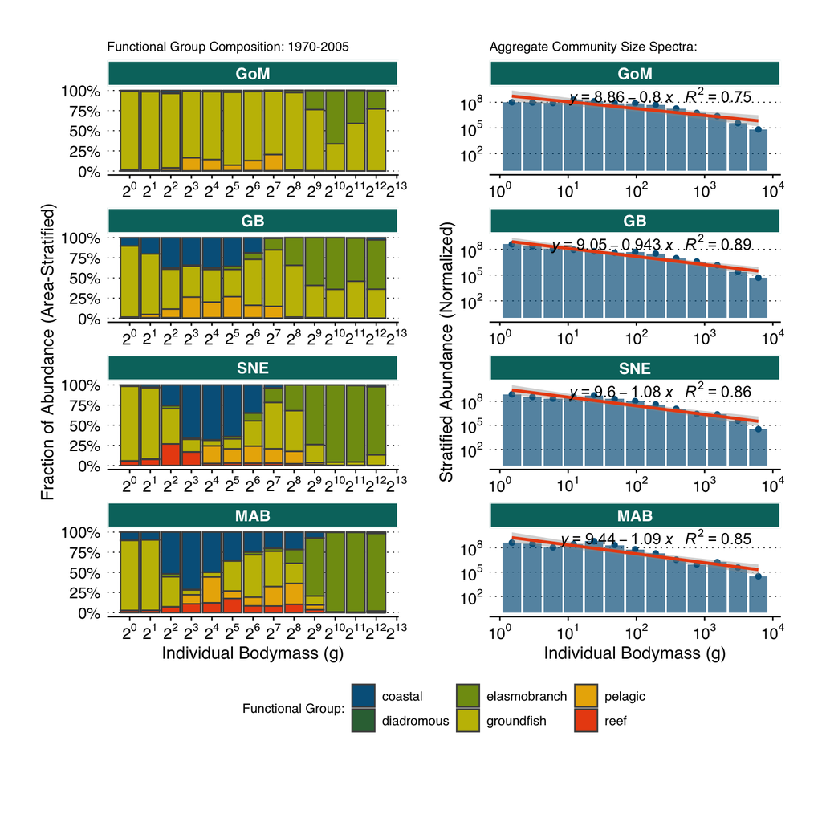

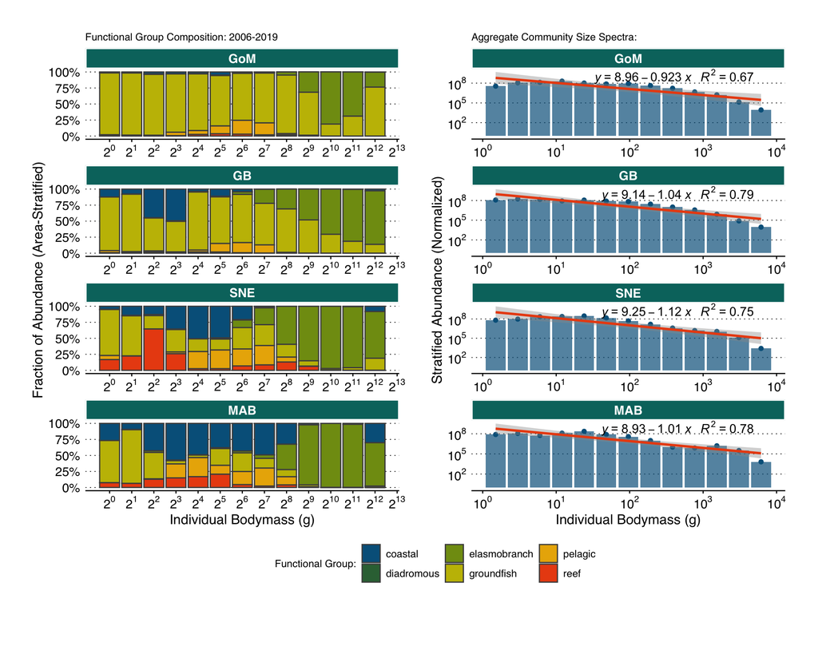

## Specific Years Where Max Size Changes

This is what a single year looks like in the most recent regime, do we see any absences in lower size groups at a yearly step?

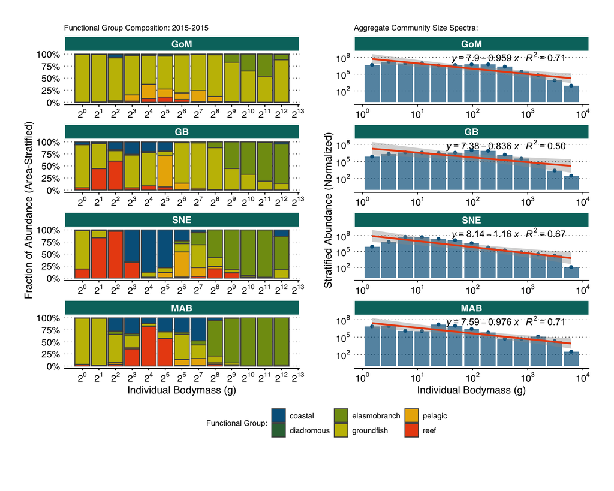

# When/Where are Size Bins Missing

This section is for documenting where and how often size bins do not have abundances present for analysis. These are the sistuations where I am testing the impacts surrounding how I treat situations where:

> If 10^4 is routinely absent in some areas, should it be kept? What if it is the result of fishing, shouldn’t the 0 biomass be meaningful?

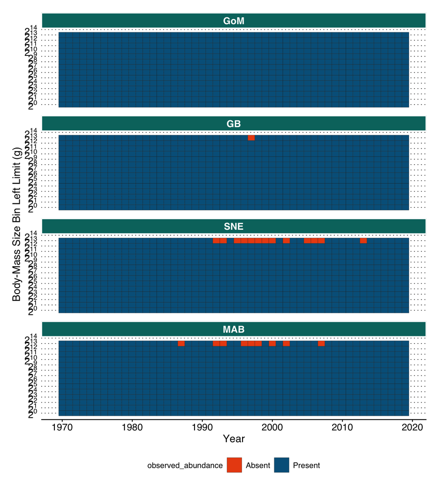

# Behavior for an Empty Bin?

Whenever a bin is empty, there is a decision to make about how to handle that gap. An `NA` value will ignore that bin exists, and ignore that there is an absence in potential biomass, biasing the slope to be more positive. Substituting small values near 0 to preserve the bin has the opposite impact, biasing a more negative slope depending on how small the substitution.

**Replace Gaps with N = 1**

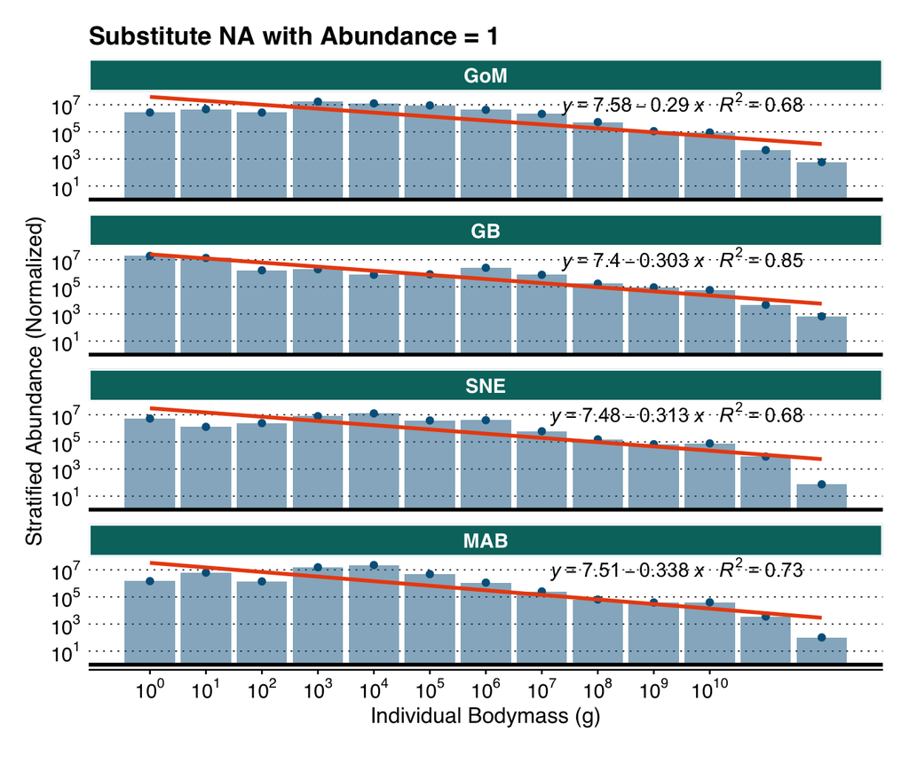

**Ignore Gaps and Lose Bins**

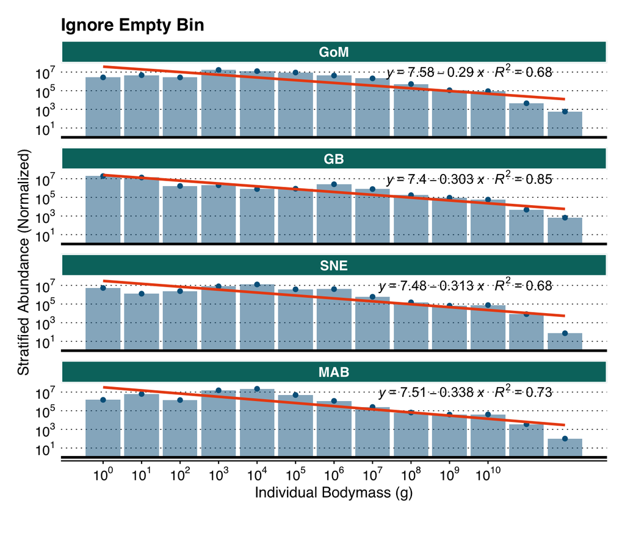

**ISD Analogs**

To pick a single year as an example, this is what Georges Bank’s ISD exponent fit changes with a change in maximum size parameter from 10^4 to 10^5.

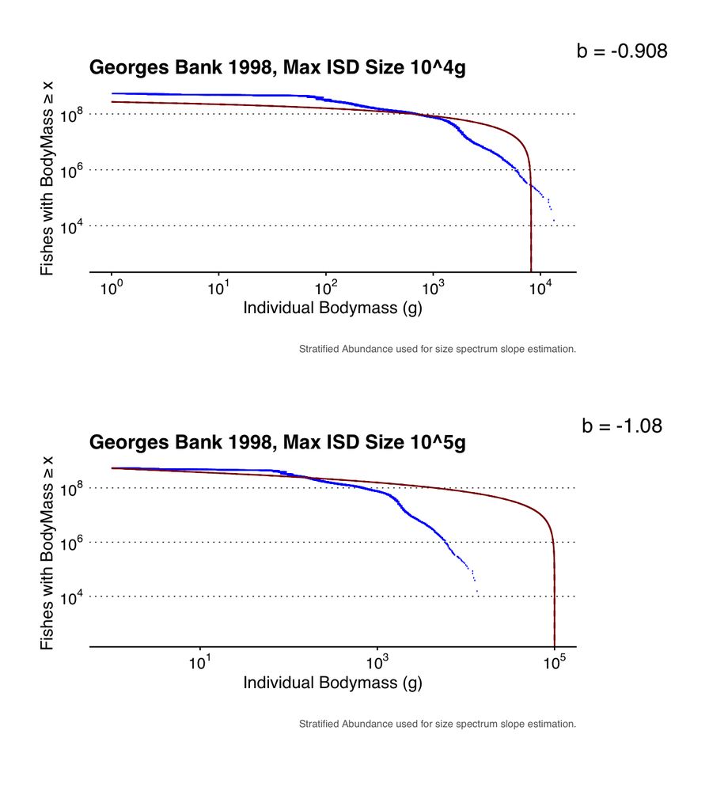

# What % of Biomass Falls within Min/Max Limits

Both the binning and ISD methodology requires some decision making around the minimum and maximum body sizes being investigated. This is either done explicitly with the min/max parameters of the ISD bounded power law, or implicitly with the smallest and largest size bins included in the slope estimates.

Under the current analysis these upper and lower limits are:

**Current Analysis Configurations:**

- lower limit: 1gram
- upper limit: 8192grams

**Using the current analysis controls:**

- 96.89% of the stratified biomass falls below the maximum size limit of 8192g.
- 99.998% of the stratified biomass falls above the minimum size limit of 1g.
- And 96.88% of the stratified total biomass falls within that min-max size range.